# Week_4_Exercises

Shannon Cheng

5/28/2020

```r
library(tidyverse)
library(nycflights13)
```

# 7.3.4 Exercises

### 1. Explore the distribution of each of the `x`, `y`, and `z` variables in `diamonds`. What do you learn? Think about a diamond and how you might decide which dimension is the length, width, and depth.

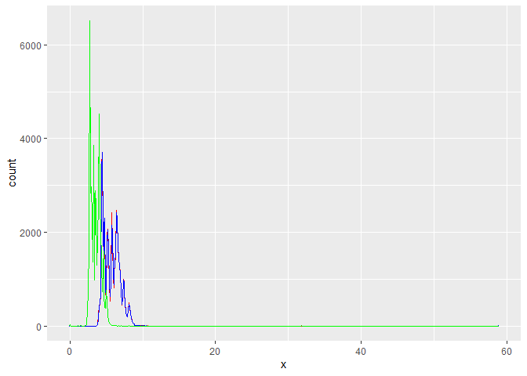

```r
ggplot(data = diamonds) +
  geom_freqpoly(binwidth=0.1,aes(x = x), color = "red") +
  geom_freqpoly(binwidth=0.1,aes(x = y), color = "blue") +
  geom_freqpoly(binwidth=0.1,aes(x = z), color  ="green")
```

### 2. Explore the distribution of price. Do you discover anything unusual or surprising? (Hint: Carefully think about the binwidth and make sure you try a wide range of values.)

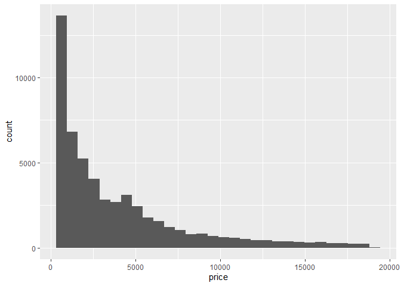

```r
ggplot(data = diamonds, aes(x = price)) +
  geom_histogram(data = diamonds, aes(x = price))
```

### 3. How many diamonds are 0.99 carat? How many are 1 carat? What do you think is the cause of the difference?

```r
filter(diamonds,carat==0.99) %>% count()
```

```
## # A tibble: 1 x 1
##       n
##   <int>
## 1    23
```

```r
filter(diamonds,carat==1) %>% count()
```

```
## # A tibble: 1 x 1
##       n
##   <int>
## 1  1558
```

### 4. Compare and contrast coord_cartesian() vs xlim() or ylim() when zooming in on a histogram. What happens if you leave binwidth unset? What happens if you try and zoom so only half a bar shows?

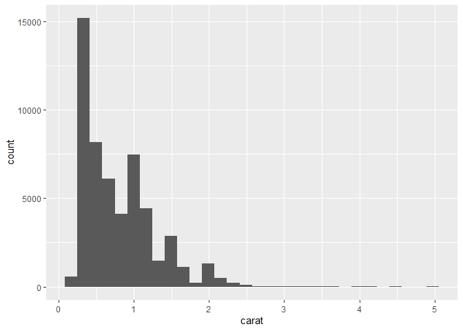

```r
diamonds %>%
  ggplot() +
  geom_histogram(aes(x = carat))
```

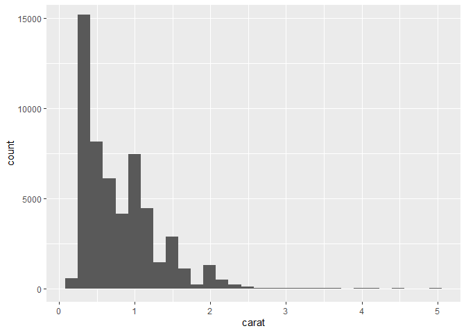

```r
diamonds %>%
  ggplot() +
  geom_histogram( aes( x = carat ) ) +
  coord_cartesian(ylim=c(0,15000))
```

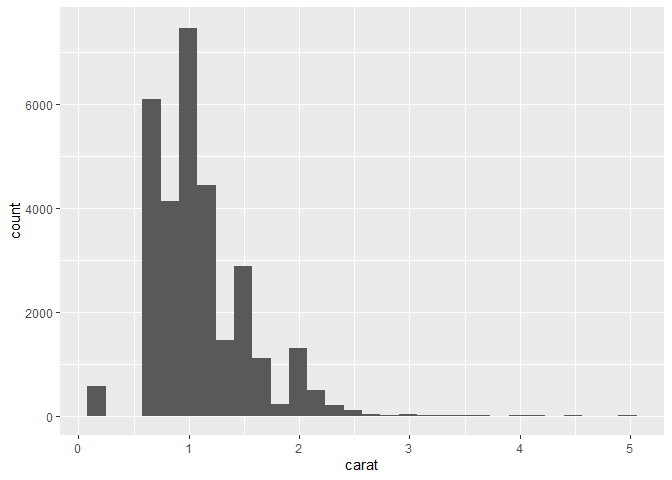

```r
diamonds %>%
  ggplot() +
  geom_histogram( aes( x = carat ) ) +
  ylim( c(0,7500) )
```

# 7.4.1 Exercises

### 1. What happens to missing values in a histogram? What happens to missing values in a bar chart? Why is there a difference?

The missing values are removed from the charts.

### 2. What does `na.rm = TRUE` do in `mean()` and `sum()`?

It removes `na` values while calculating mean and sum.

# 7.5.1.1 Exercises

### 1. Use what you’ve learned to improve the visualisation of the departure times of cancelled vs. non-cancelled flights.

```r
library(nycflights13)
```

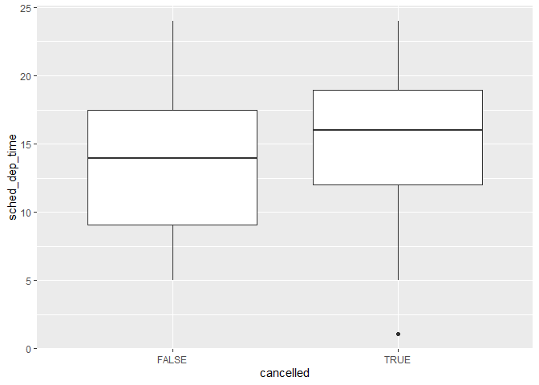

```r
nycflights13::flights %>%
  mutate(
    cancelled=is.na(dep_time),
    sched_hour=sched_dep_time %/% 100,
    sched_min=sched_dep_time %% 100,
    sched_dep_time=sched_hour + sched_min / 60
  ) %>%
  ggplot() +
  geom_boxplot(mapping=aes(y=sched_dep_time, x=cancelled))
```

### 2. What variable in the diamonds dataset is most important for predicting the price of a diamond? How is that variable correlated with cut? Why does the combination of those two relationships lead to lower quality diamonds being more expensive?

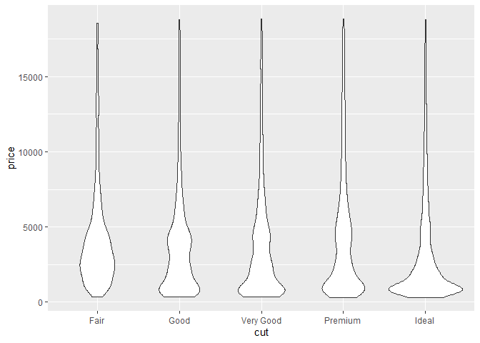

```r
ggplot(data=diamonds)+
  geom_violin(mapping=aes(x=cut, y=price))
```

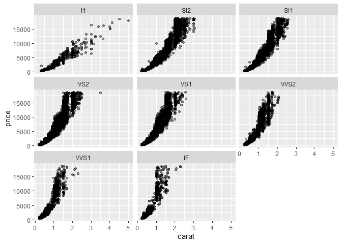

```r
ggplot(data=diamonds)+
  geom_point(mapping=aes(x=carat, y=price), alpha=0.4)+
  facet_wrap(~clarity)
```

### 3.Install the ggstance package, and create a horizontal boxplot. How does this compare to using `coord_flip()`?

```r
library(ggstance)
```

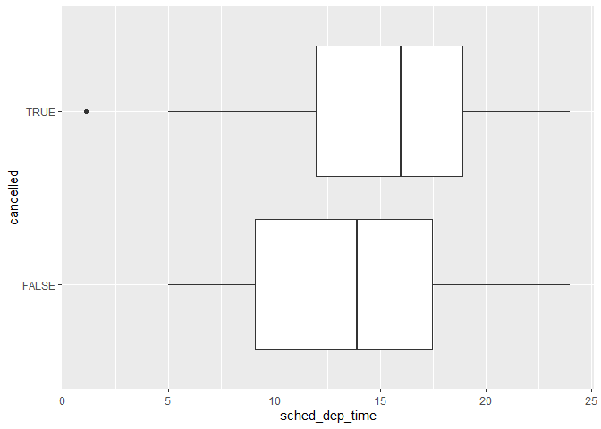

```r
nycflights13::flights %>%
  mutate(
    cancelled=is.na(dep_time),
    sched_hour=sched_dep_time %/% 100,
    sched_min=sched_dep_time %% 100,
    sched_dep_time=sched_hour + sched_min / 60
  ) %>%
ggplot()+
  geom_boxploth(mapping=aes(y=cancelled, x=sched_dep_time))
```

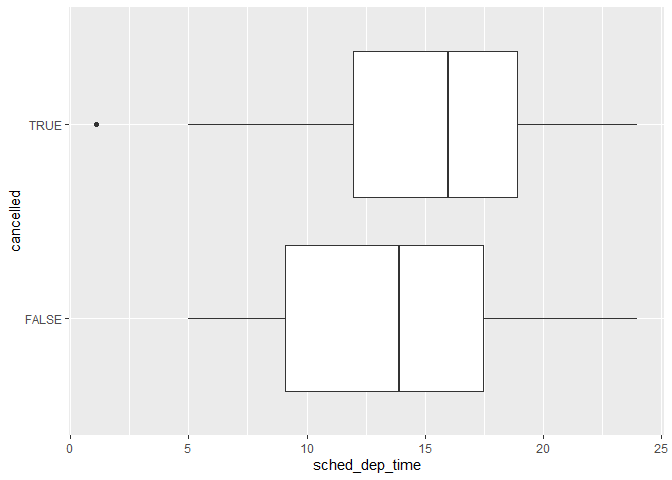

```r
nycflights13::flights %>%
  mutate(
    cancelled=is.na(dep_time),
    sched_hour=sched_dep_time %/% 100,
    sched_min=sched_dep_time %% 100,
    sched_dep_time=sched_hour + sched_min / 60
  ) %>%
  ggplot()+
  geom_boxplot(mapping=aes(y=sched_dep_time, x=cancelled))+
  coord_flip()
```

### 5.Compare and contrast `geom_violin()` with a facetted `geom_histogram()`, or a coloured `geom_freqpoly()`. What are the pros and cons of each method?

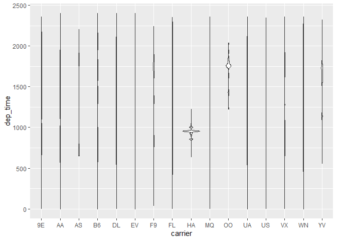

```r
nycflights13::flights %>%
  mutate(
    cancelled=is.na(dep_time),
    sched_hour=sched_dep_time %/% 100,
    sched_min=sched_dep_time %% 100,
    sched_dep_time=sched_hour + sched_min / 60
  ) %>%
ggplot()+
  geom_violin(mapping=aes(x=carrier,y=dep_time))
```

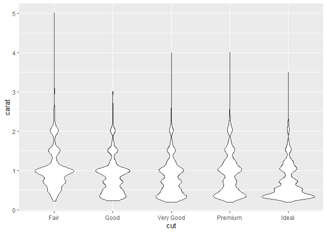

```r
ggplot(data=diamonds)+
  geom_violin(mapping=aes(x=cut, y=carat))
```

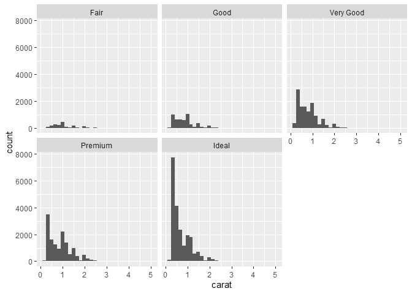

```r
ggplot(data=diamonds)+
  geom_histogram(mapping=aes(x=carat))+
  facet_wrap(~cut)
```

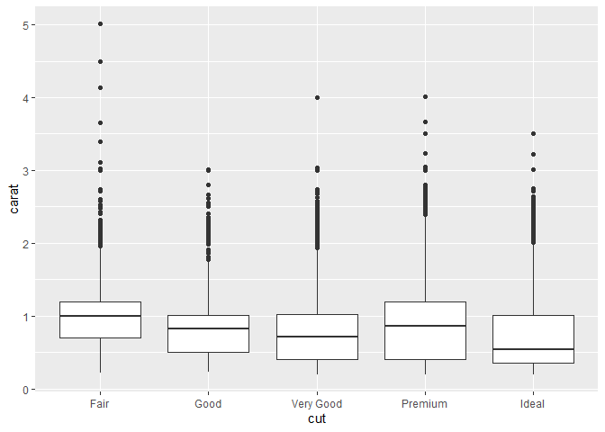

```r
ggplot(data=diamonds)+
  geom_boxplot(mapping=aes(x=cut, y=carat))
```

### 6.If you have a small dataset, it’s sometimes useful to use `geom_jitter()` to see the relationship between a continuous and categorical variable. The ggbeeswarm package provides a number of methods similar to `geom_jitter()`. List them and briefly describe what each one does.

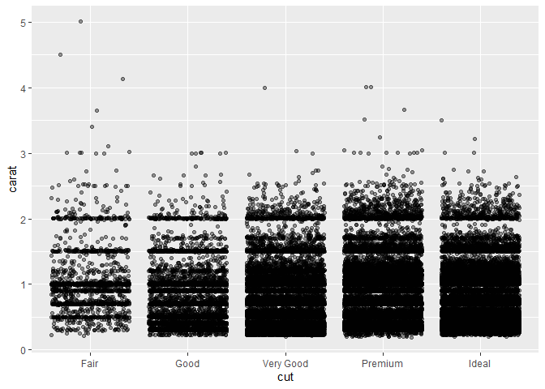

```r
ggplot(data=diamonds)+
  geom_jitter(mapping=aes(x=cut, y=carat), alpha=0.4, dodge.width=0.8)
```

# 7.5.2 Exercises

### Describe an experiment that would have 2 categorical variables.

##### Arabidopsis seed packet families vs. existence of luciferase promoter.

# 7.5.3 Exercises

### Describe an experiment that would have 2 continuous variables.

##### Arabidopsis hypocotyl length vs. days since germination.